# 13 Session 13: Area Data V

# Activity 14: Area Data V

## Practice questions

Answer the following questions:

1. Explain the main assumptions for linear regression models.
2. How is Moran’s I used as a diagnostic in regression analysis?
3. Residual spatial autocorrelation is symptomatic of what issues in regression analysis?
4. What does it mean for a model to be linear in the coefficients?
5. What is the purpose of transforming variables for regression analysis?

## Learning objectives

In this activity, you will:

1. Explore a spatial dataset.
2. Conduct linear regression analysis.
3. Conduct diagnostics for residual spatial autocorrelation.
4. Propose ways to improve your analysis.

## Suggested reading

O’Sullivan D and Unwin D (2010) Geographic Information Analysis, 2nd Edition, Chapter 7. John Wiley & Sons: New Jersey.

## Preliminaries

For this activity you will need the following:

For this activity you will need the following:

- An R markdown notebook version of this document (the source file).
- A package called `geog4ga3`.

It is good practice to clear the working space to make sure that you do not have extraneous items there when you begin your work. The command in R to clear the workspace is `rm` (for “remove”), followed by a list of items to be removed. To clear the workspace from *all* objects, do the following:

```r
rm(list = ls())
```

Note that `ls()` lists all objects currently on the worspace.

Load the libraries you will use in this activity. In addition to `tidyverse`, you will need `sf` and `geog4ga3`:

```r
library(tidyverse)
library(sf)
library(spdep)
library(geog4ga3)
```

Begin by loading the data files you will use in this activity:

```r
data("HamiltonDAs")
data("trips_by_mode")
data("travel_time_car")
```

`HamiltonDAs` are the Dissemination Areas for Hamilton CMA, which coincide with the Traffic Analysis Zones (TAZ) of the Transportation Tomorrow Survey of 2011. The dataframe `trips_by_mode` includes the number of trips by mode of transportation by TAZ (equivalently DA), as well as other useful information from the 2011 census for Hamilton CMA. Finally, the dataframe `travel_time_car` includes the travel distance/time from TAZ/DA centroids to Jackson Square in downtown Hamilton.

The data for this activity were retrieved from the 2011 Transportation Tomorrow Survey [TTS](http://www.transportationtomorrow.on.ca/), the periodic travel survey of the Greater Toronto and Hamilton Area, as well as data from the 2011 Canadian Census [Census Program](http://www12.statcan.gc.ca/census-recensement/index-eng.cfm).

Before beginning the activity, join the information on trips and travel time to the `sf` object. Note that to complete the join, the identifier (in this case `GTA06`) must be in the same format in both data frames:

```r
travel_time_car$GTA06 <- factor(travel_time_car$GTA06)
# Travel time
HamiltonDAs <- left_join(HamiltonDAs, travel_time_car, by = "GTA06")
# Trips by mode
HamiltonDAs <- left_join(HamiltonDAs, trips_by_mode, by = "GTA06")
```

```
Column `GTA06` joining factor and character vector, coercing into character vector
```

The analysis will be based on travel by car in the Hamilton CMA. Calculate the proportion of trips by car by TAZ:

```r
HamiltonDAs <- mutate(HamiltonDAs, Auto_driver.prop = Auto_driver / (Auto_driver + Cycle + Walk))
```

Note that the proportion of people who travelled by car as passengers are not included in the denominator of the proportion! This is because every trip as a passenger is already included in trips with one driver.

## Activity

1. Examine your dataframe. What variables are included? Are there any missing values?
2. Map the variable `Auto_driver.prop`, and use Moran’s I to test for spatial autocorrelation. What do you find? Is autocorrelation in this variable a sign that autocorrelation will be an issue in regression analysis?

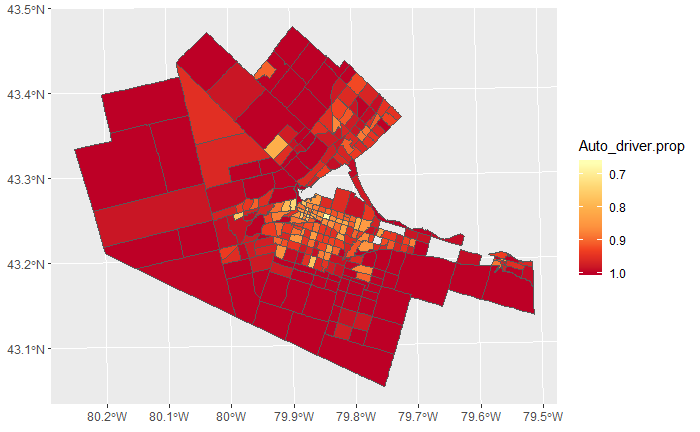

```r
ggplot(data = HamiltonDAs, aes(fill = Auto_driver.prop)) +
  geom_sf() +
  scale_fill_distiller(palette = "YlOrRd", trans = "reverse")
```

Create spatial weights matrix.

```r
HamiltonDAs.w <- nb2listw(poly2nb(as(HamiltonDAs, "Spatial")))
```

Calculate Moran’s I.

```r
moran.test(HamiltonDAs$Auto_driver.prop, HamiltonDAs.w)
```

```
    Moran I test under randomisation

data:  HamiltonDAs$Auto_driver.prop
weights: HamiltonDAs.w

Moran I statistic standard deviate = 12.944, p-value < 2.2e-16
alternative hypothesis: greater
sample estimates:
Moran I statistic       Expectation          Variance
      0.436385034      -0.003378378       0.001154235
```

3. Estimate regression model using the variables `Pop_Density` and travel time in `minutes`. Discuss this model.

```r
model <- lm(formula = Auto_driver.prop ~ Pop_Density + minutes, data = HamiltonDAs)
summary(model)
```

```
Call:
lm(formula = Auto_driver.prop ~ Pop_Density + minutes, data = HamiltonDAs)

Residuals:
      Min        1Q    Median        3Q       Max
-0.190533 -0.009719  0.010093  0.025149  0.136922

Coefficients:
              Estimate Std. Error t value Pr(>|t|)
(Intercept)  9.370e-01  1.064e-02   88.03  < 2e-16 ***
Pop_Density -1.464e-05  1.436e-06  -10.20  < 2e-16 ***
minutes      2.199e-03  4.650e-04    4.73  3.5e-06 ***
---
Signif. codes:  0 ‘***’ 0.001 ‘**’ 0.01 ‘*’ 0.05 ‘.’ 0.1 ‘ ’ 1

Residual standard error: 0.04546 on 294 degrees of freedom
Multiple R-squared:  0.482, Adjusted R-squared:  0.4784
F-statistic: 136.8 on 2 and 294 DF,  p-value: < 2.2e-16
```

4. Examine residuals of the model. Are they spatially independent?

```r
moran.test(model$residuals, HamiltonDAs.w)
```

```
    Moran I test under randomisation

data:  model$residuals
weights: HamiltonDAs.w

Moran I statistic standard deviate = 2.0824, p-value = 0.01865
alternative hypothesis: greater
sample estimates:
Moran I statistic       Expectation          Variance
      0.067136966      -0.003378378       0.001146675
```

5. Propose ways to improve your model.

Create a histogram:

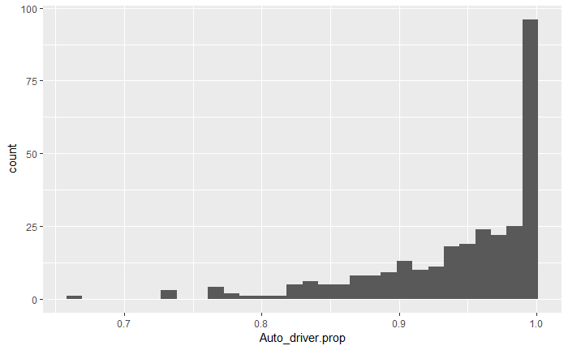

```r
ggplot(data = HamiltonDAs, aes(x = Auto_driver.prop)) + geom_histogram()
```

Scatterplots:

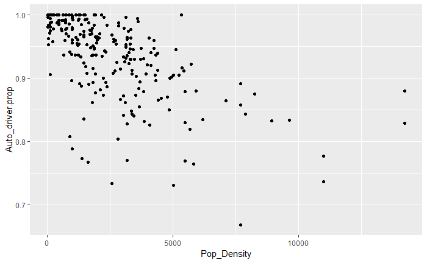

```r
ggplot(data = HamiltonDAs, aes(x = Pop_Density, y = Auto_driver.prop)) +
  geom_point()
```

Data transformation: Model:

```r
model2 <- lm(formula = log(Auto_driver.prop) ~ Pop_Density + minutes + Median_income + Employment_rate, data = HamiltonDAs)
summary(model2)
```

```
Call:
lm(formula = log(Auto_driver.prop) ~ Pop_Density + minutes +
    Median_income + Employment_rate, data = HamiltonDAs)

Residuals:
      Min        1Q    Median        3Q       Max
-0.223556 -0.013224  0.009366  0.027012  0.138708

Coefficients:
                  Estimate Std. Error t value Pr(>|t|)
(Intercept)     -1.157e-01  2.610e-02  -4.434 1.31e-05 ***
Pop_Density     -1.424e-05  1.772e-06  -8.037 2.30e-14 ***
minutes          2.176e-03  5.379e-04   4.045 6.70e-05 ***
Median_income    1.057e-06  5.257e-07   2.010   0.0454 *
Employment_rate  2.156e-04  4.465e-04   0.483   0.6295
---
Signif. codes:  0 ‘***’ 0.001 ‘**’ 0.01 ‘*’ 0.05 ‘.’ 0.1 ‘ ’ 1

Residual standard error: 0.0511 on 292 degrees of freedom
Multiple R-squared:  0.4814,    Adjusted R-squared:  0.4743
F-statistic: 67.76 on 4 and 292 DF,  p-value: < 2.2e-16
```

Test for spatial autocorrelation:

```r
moran.test(model2$residuals, HamiltonDAs.w)
```

```
    Moran I test under randomisation

data:  model2$residuals
weights: HamiltonDAs.w

Moran I statistic standard deviate = 1.2688, p-value = 0.1022
alternative hypothesis: greater
sample estimates:
Moran I statistic       Expectation          Variance
      0.039527508      -0.003378378       0.001143461
```